# Data Preparation

```python
import pandas as pd
import numpy as np
from functools import reduce
import math

from sklearn.model_selection import GridSearchCV
from sklearn.model_selection import cross_val_score #,  cross_validate
from sklearn.ensemble import GradientBoostingClassifier
from sklearn import metrics
# from sklearn import cross_validation, metrics
# from sklearn.grid_search import GridSearchCV

import matplotlib.pylab as plt
%matplotlib inline
```

```python
event_type = pd.read_csv('event_type.csv')
log_feature = pd.read_csv('log_feature.csv')
resource_type = pd.read_csv('resource_type.csv')
severity_type = pd.read_csv('severity_type.csv')
train = pd.read_csv('train.csv')

# This is an Inner Join by default and will only include IDs that are present in all dataframes (the intersection of all data files)
# This is ok, because the model should only be trained on ID's present in the train dataset.  There are 7381 unique IDs in the train dataset
csv_list = [event_type,log_feature,resource_type,severity_type,train]
```

###### Merge datasets on ID

```python
df = reduce(lambda left,right: pd.merge(left,right,on='id'), csv_list)
```

###### Remove all non-numeric characters

```python
# str.extract uses regex pattern to extract all numeric charcters
df.event_type = df.event_type.str.extract('(\d+)',expand=False)
df.log_feature = df.log_feature.str.extract('(\d+)',expand=False)
df.resource_type = df.resource_type.str.extract('(\d+)',expand=False)
df.severity_type = df.severity_type.str.extract('(\d+)',expand=False)
df.location = df.location.str.extract('(\d+)',expand=False)
```

```python
df.head()
```

|  | id | event_type | log_feature | volume | resource_type | severity_type | location | fault_severity |
| --- | --- | --- | --- | --- | --- | --- | --- | --- |
| 0 | 8011 | 15 | 68 | 7 | 8 | 2 | 1 | 0 |
| 1 | 2588 | 15 | 82 | 9 | 8 | 1 | 1 | 0 |
| 2 | 2588 | 15 | 201 | 5 | 8 | 1 | 1 | 0 |
| 3 | 2588 | 15 | 80 | 15 | 8 | 1 | 1 | 0 |
| 4 | 2588 | 15 | 203 | 5 | 8 | 1 | 1 | 0 |

```python
X = df.drop('fault_severity', axis=1)
```

```python
y = df[['id','fault_severity']]
```

Verify that there are the same number of unique IDs in both X and y

```python
y.id.nunique()
```

```
7381
```

```python
X.id.nunique()
```

```
7381
```

###### 'id' and 'volume' are ints. The rest are categorical according to the data dictionary. X is ready to be changed into dummy columns using pd.getdummies()

```python
X.info()
```

```
<class 'pandas.core.frame.DataFrame'>
Int64Index: 61839 entries, 0 to 61838
Data columns (total 7 columns):
id               61839 non-null int64
event_type       61839 non-null object
log_feature      61839 non-null object
volume           61839 non-null int64
resource_type    61839 non-null object
severity_type    61839 non-null object
location         61839 non-null object
dtypes: int64(2), object(5)
memory usage: 3.8+ MB
```

```python
X = pd.get_dummies(X)
```

```python
X.columns
```

```
Index(['id', 'volume', 'event_type_1', 'event_type_10', 'event_type_11',
       'event_type_12', 'event_type_13', 'event_type_14', 'event_type_15',
       'event_type_18',
       ...
       'location_987', 'location_989', 'location_99', 'location_990',
       'location_991', 'location_994', 'location_995', 'location_996',
       'location_998', 'location_999'],
      dtype='object', length=1326)
```

Check that the get_dummies() worked as expected

```python
X.head()
```

|  | id | volume | event_type_1 | event_type_10 | event_type_11 | event_type_12 | event_type_13 | event_type_14 | event_type_15 | event_type_18 | ... | location_987 | location_989 | location_99 | location_990 | location_991 | location_994 | location_995 | location_996 | location_998 | location_999 |
| --- | --- | --- | --- | --- | --- | --- | --- | --- | --- | --- | --- | --- | --- | --- | --- | --- | --- | --- | --- | --- | --- |
| 0 | 8011 | 7 | 0 | 0 | 0 | 0 | 0 | 0 | 1 | 0 | ... | 0 | 0 | 0 | 0 | 0 | 0 | 0 | 0 | 0 | 0 |
| 1 | 2588 | 9 | 0 | 0 | 0 | 0 | 0 | 0 | 1 | 0 | ... | 0 | 0 | 0 | 0 | 0 | 0 | 0 | 0 | 0 | 0 |
| 2 | 2588 | 5 | 0 | 0 | 0 | 0 | 0 | 0 | 1 | 0 | ... | 0 | 0 | 0 | 0 | 0 | 0 | 0 | 0 | 0 | 0 |
| 3 | 2588 | 15 | 0 | 0 | 0 | 0 | 0 | 0 | 1 | 0 | ... | 0 | 0 | 0 | 0 | 0 | 0 | 0 | 0 | 0 | 0 |
| 4 | 2588 | 5 | 0 | 0 | 0 | 0 | 0 | 0 | 1 | 0 | ... | 0 | 0 | 0 | 0 | 0 | 0 | 0 | 0 | 0 | 0 |

5 rows × 1326 columns

There are multiple IDs with different combinations of features. Combine the features with a grouby().max().

```python
X = X.groupby('id').max()
```

Check that the groupby worked as expected. There should be no dummy variables with values != 0 or 1

```python
X.head()
```

| id | volume | event_type_1 | event_type_10 | event_type_11 | event_type_12 | event_type_13 | event_type_14 | event_type_15 | event_type_18 | event_type_19 | ... | location_987 | location_989 | location_99 | location_990 | location_991 | location_994 | location_995 | location_996 | location_998 | location_999 |
| --- | --- | --- | --- | --- | --- | --- | --- | --- | --- | --- | --- | --- | --- | --- | --- | --- | --- | --- | --- | --- | --- |
| 1 | 2 | 0 | 0 | 1 | 0 | 1 | 0 | 0 | 0 | 0 | ... | 0 | 0 | 0 | 0 | 0 | 0 | 0 | 0 | 0 | 0 |
| 5 | 11 | 0 | 0 | 0 | 0 | 0 | 0 | 0 | 0 | 0 | ... | 0 | 0 | 0 | 0 | 0 | 0 | 0 | 0 | 0 | 0 |
| 6 | 1 | 0 | 0 | 0 | 0 | 0 | 0 | 0 | 0 | 0 | ... | 0 | 0 | 0 | 0 | 0 | 0 | 0 | 0 | 0 | 0 |
| 8 | 5 | 0 | 0 | 0 | 0 | 0 | 0 | 0 | 0 | 0 | ... | 0 | 0 | 0 | 0 | 0 | 0 | 0 | 0 | 0 | 0 |
| 13 | 1 | 0 | 0 | 0 | 0 | 0 | 0 | 0 | 0 | 0 | ... | 0 | 0 | 0 | 0 | 0 | 0 | 0 | 0 | 0 | 0 |

5 rows × 1325 columns

```python
X['id'] = X.index
```

```python
X.head()
```

| id | volume | event_type_1 | event_type_10 | event_type_11 | event_type_12 | event_type_13 | event_type_14 | event_type_15 | event_type_18 | event_type_19 | ... | location_989 | location_99 | location_990 | location_991 | location_994 | location_995 | location_996 | location_998 | location_999 | id |
| --- | --- | --- | --- | --- | --- | --- | --- | --- | --- | --- | --- | --- | --- | --- | --- | --- | --- | --- | --- | --- | --- |
| 1 | 2 | 0 | 0 | 1 | 0 | 1 | 0 | 0 | 0 | 0 | ... | 0 | 0 | 0 | 0 | 0 | 0 | 0 | 0 | 0 | 1 |
| 5 | 11 | 0 | 0 | 0 | 0 | 0 | 0 | 0 | 0 | 0 | ... | 0 | 0 | 0 | 0 | 0 | 0 | 0 | 0 | 0 | 5 |
| 6 | 1 | 0 | 0 | 0 | 0 | 0 | 0 | 0 | 0 | 0 | ... | 0 | 0 | 0 | 0 | 0 | 0 | 0 | 0 | 0 | 6 |
| 8 | 5 | 0 | 0 | 0 | 0 | 0 | 0 | 0 | 0 | 0 | ... | 0 | 0 | 0 | 0 | 0 | 0 | 0 | 0 | 0 | 8 |
| 13 | 1 | 0 | 0 | 0 | 0 | 0 | 0 | 0 | 0 | 0 | ... | 0 | 0 | 0 | 0 | 0 | 0 | 0 | 0 | 0 | 13 |

5 rows × 1326 columns

Modifying 'volume' field had no significant effect on the results

```python
X.volume = X.volume/X.volume.max()

X.head()
```

| id | volume | event_type_1 | event_type_10 | event_type_11 | event_type_12 | event_type_13 | event_type_14 | event_type_15 | event_type_18 | event_type_19 | ... | location_989 | location_99 | location_990 | location_991 | location_994 | location_995 | location_996 | location_998 | location_999 | id |
| --- | --- | --- | --- | --- | --- | --- | --- | --- | --- | --- | --- | --- | --- | --- | --- | --- | --- | --- | --- | --- | --- |
| 1 | 0.002281 | 0 | 0 | 1 | 0 | 1 | 0 | 0 | 0 | 0 | ... | 0 | 0 | 0 | 0 | 0 | 0 | 0 | 0 | 0 | 1 |
| 5 | 0.012543 | 0 | 0 | 0 | 0 | 0 | 0 | 0 | 0 | 0 | ... | 0 | 0 | 0 | 0 | 0 | 0 | 0 | 0 | 0 | 5 |
| 6 | 0.001140 | 0 | 0 | 0 | 0 | 0 | 0 | 0 | 0 | 0 | ... | 0 | 0 | 0 | 0 | 0 | 0 | 0 | 0 | 0 | 6 |
| 8 | 0.005701 | 0 | 0 | 0 | 0 | 0 | 0 | 0 | 0 | 0 | ... | 0 | 0 | 0 | 0 | 0 | 0 | 0 | 0 | 0 | 8 |
| 13 | 0.001140 | 0 | 0 | 0 | 0 | 0 | 0 | 0 | 0 | 0 | ... | 0 | 0 | 0 | 0 | 0 | 0 | 0 | 0 | 0 | 13 |

5 rows × 1326 columns

# Data Modeling

```python
# dtrain includes X and y column
dtrain = X[:]
target = 'fault_severity'
predictors = [x for x in X.columns if x not in [target, 'id']]
```

```python
len(dtrain)
```

```
7381
```

```python
len(y)
```

```
61839
```

```python
dtrain[target]= y.groupby('id').max()
```

```python
dtrain.head()
```

| id | volume | event_type_1 | event_type_10 | event_type_11 | event_type_12 | event_type_13 | event_type_14 | event_type_15 | event_type_18 | event_type_19 | ... | location_99 | location_990 | location_991 | location_994 | location_995 | location_996 | location_998 | location_999 | id | fault_severity |
| --- | --- | --- | --- | --- | --- | --- | --- | --- | --- | --- | --- | --- | --- | --- | --- | --- | --- | --- | --- | --- | --- |
| 1 | 0.002281 | 0 | 0 | 1 | 0 | 1 | 0 | 0 | 0 | 0 | ... | 0 | 0 | 0 | 0 | 0 | 0 | 0 | 0 | 1 | 1 |
| 5 | 0.012543 | 0 | 0 | 0 | 0 | 0 | 0 | 0 | 0 | 0 | ... | 0 | 0 | 0 | 0 | 0 | 0 | 0 | 0 | 5 | 0 |
| 6 | 0.001140 | 0 | 0 | 0 | 0 | 0 | 0 | 0 | 0 | 0 | ... | 0 | 0 | 0 | 0 | 0 | 0 | 0 | 0 | 6 | 1 |
| 8 | 0.005701 | 0 | 0 | 0 | 0 | 0 | 0 | 0 | 0 | 0 | ... | 0 | 0 | 0 | 0 | 0 | 0 | 0 | 0 | 8 | 0 |
| 13 | 0.001140 | 0 | 0 | 0 | 0 | 0 | 0 | 0 | 0 | 0 | ... | 0 | 0 | 0 | 0 | 0 | 0 | 0 | 0 | 13 | 0 |

5 rows × 1327 columns

```python
dtrain.to_csv('pbl0_cleaned.csv')
```

```python
dtrain[target]
```

```
id
1        1
5        0
6        1
8        0
13       0
19       1
20       0
23       0
24       0
26       0
27       0
28       0
29       0
31       0
```

[output cut: 48 more lines]

```python
# dtrain[target] = y.groupby('id')[target].max()
```

```python
def modelfit(alg, dtrain, predictors, performCV=True, printFeatureImportance=True, num_top_features=30, cv_folds=3):

    alg.fit(dtrain[predictors], dtrain[target])

    #Predict training set:
    dtrain_predictions = alg.predict(dtrain[predictors])
    dtrain_predprob = alg.predict_proba(dtrain[predictors])

    #Perform cross-validation:
    if performCV:
        cv_score = cross_val_score(alg, dtrain[predictors], dtrain[target], cv=cv_folds, scoring='accuracy', n_jobs=-1)

    #Print model report:
    print ("\nModel Report")
    print ("Accuracy : %.4g" % metrics.accuracy_score(dtrain[target].values, dtrain_predictions))

    if performCV:
        print ("CV Score : Mean - %.7g | Std - %.7g | Min - %.7g | Max - %.7g" % (np.mean(cv_score),np.std(cv_score),np.min(cv_score),np.max(cv_score)))

    #Print Feature Importance:
    if printFeatureImportance:
        feat_imp = pd.Series(alg.feature_importances_, predictors).sort_values(ascending=False).head(num_top_features)
        feat_imp.plot(kind='barh', title='Feature Importances', figsize=(6,6))
        plt.ylabel('Feature Importance Score')

    return dtrain_predictions, dtrain_predprob
```

```
Model Report
Accuracy : 0.7588
CV Score : Mean - 0.734453 | Std - 0.001320905 | Min - 0.7332249 | Max - 0.7362861
```

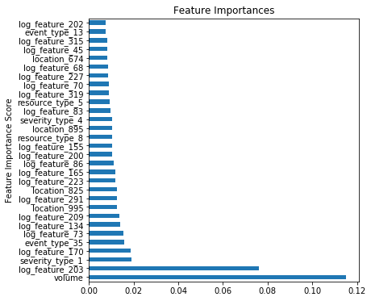

```python
gbm0 = GradientBoostingClassifier(random_state=1)
gbm0_pred, gbm0_predproba = modelfit(gbm0, dtrain, predictors, performCV=True, printFeatureImportance=True)
```

The default GradientBoostingClassifier has the following hyperparameters

```python
gbm0.get_params
```

```
<bound method BaseEstimator.get_params of GradientBoostingClassifier(criterion='friedman_mse', init=None,
              learning_rate=0.1, loss='deviance', max_depth=3,
              max_features=None, max_leaf_nodes=None,
              min_impurity_decrease=0.0, min_impurity_split=None,
              min_samples_leaf=1, min_samples_split=2,
              min_weight_fraction_leaf=0.0, n_estimators=100,
              presort='auto', random_state=1, subsample=1.0, verbose=0,
              warm_start=False)>
```

The array below is the probability of fault_0, fault_1, fault_2, for all IDs in the training set

```python
gbm0_predproba
```

```
array([[ 0.45690216,  0.49524431,  0.04785353],
       [ 0.71503098,  0.27513577,  0.00983325],
       [ 0.5696948 ,  0.41977706,  0.01052814],
       ...,
       [ 0.59814907,  0.36542972,  0.03642121],
       [ 0.92405098,  0.06897008,  0.00697894],
       [ 0.61622069,  0.34725127,  0.03652804]])
```

### Tuning Hyperparameters with GridSearchCV

General advice for tuning parameters

1. **Choose a relatively high learning rate**. Generally the default value of 0.1 works but somewhere between 0.05 to 0.2 should work for different problems
2. Determine the **optimum number of trees for this learning rate**. This should range around 40-70. Remember to choose a value on which your system can work fairly fast. This is because it will be used for testing various scenarios and determining the tree parameters.
3. **Tune tree-specific parameters** for decided learning rate and number of trees. Note that we can choose different parameters to define a tree and I’ll take up an example here.
4. **Lower the learning rate and increase the estimators** proportionally to get more robust models.

Source: https://www.analyticsvidhya.com/blog/2016/02/complete-guide-parameter-tuning-gradient-boosting-gbm-python/

#### Gradient Boosted Classifer parameters that may improve accuracy

Tree-Specific parameters:

1. min_samples_split
2. min_samples_leaf
3. min_weight_fraction_leaf
4. max_depth
5. max_leaf_nodes
6. max_features

Boosting parameters:

1. learning_rate
2. n_estimators
3. subsample

```python
predictors = [x for x in X.columns if x not in [target, 'id']]

parameters = {
#     'learning_rate':[0.1,0.05],
    'max_depth':[3,7,11],
    'min_samples_leaf':[3,9],
    'n_estimators':[100,500,1500],
    'subsample':[0.5,0.8]
}
grid = GridSearchCV(GradientBoostingClassifier(max_features='sqrt', random_state=1), parameters, scoring='accuracy', cv=3, n_jobs=-1)
grid.fit(dtrain[predictors], dtrain[target])
grid.grid_scores_, grid.best_params_, grid.best_score_
```

```
([mean: 0.70831, std: 0.00194, params: {'max_depth': 3, 'min_samples_leaf': 3, 'n_estimators': 100, 'subsample': 0.5},
  mean: 0.71074, std: 0.00467, params: {'max_depth': 3, 'min_samples_leaf': 3, 'n_estimators': 100, 'subsample': 0.8},
  mean: 0.73283, std: 0.00365, params: {'max_depth': 3, 'min_samples_leaf': 3, 'n_estimators': 500, 'subsample': 0.5},
  mean: 0.73418, std: 0.00469, params: {'max_depth': 3, 'min_samples_leaf': 3, 'n_estimators': 500, 'subsample': 0.8},
  mean: 0.73337, std: 0.00431, params: {'max_depth': 3, 'min_samples_leaf': 3, 'n_estimators': 1500, 'subsample': 0.5},
  mean: 0.73459, std: 0.00306, params: {'max_depth': 3, 'min_samples_leaf': 3, 'n_estimators': 1500, 'subsample': 0.8},
  mean: 0.70681, std: 0.00391, params: {'max_depth': 3, 'min_samples_leaf': 9, 'n_estimators': 100, 'subsample': 0.5},
  mean: 0.70790, std: 0.00493, params: {'max_depth': 3, 'min_samples_leaf': 9, 'n_estimators': 100, 'subsample': 0.8},
  mean: 0.72917, std: 0.00282, params: {'max_depth': 3, 'min_samples_leaf': 9, 'n_estimators': 500, 'subsample': 0.5},
  mean: 0.73296, std: 0.00274, params: {'max_depth': 3, 'min_samples_leaf': 9, 'n_estimators': 500, 'subsample': 0.8},
  mean: 0.73120, std: 0.00367, params: {'max_depth': 3, 'min_samples_leaf': 9, 'n_estimators': 1500, 'subsample': 0.5},
  mean: 0.73323, std: 0.00475, params: {'max_depth': 3, 'min_samples_leaf': 9, 'n_estimators': 1500, 'subsample': 0.8},
  mean: 0.73337, std: 0.00212, params: {'max_depth': 7, 'min_samples_leaf': 3, 'n_estimators': 100, 'subsample': 0.5},
  mean: 0.73229, std: 0.00324, params: {'max_depth': 7, 'min_samples_leaf': 3, 'n_estimators': 100, 'subsample': 0.8},
  mean: 0.73486, std: 0.00465, params: {'max_depth': 7, 'min_samples_leaf': 3, 'n_estimators': 500, 'subsample': 0.5},
  mean: 0.73703, std: 0.00723, params: {'max_depth': 7, 'min_samples_leaf': 3, 'n_estimators': 500, 'subsample': 0.8},
  mean: 0.72958, std: 0.00557, params: {'max_depth': 7, 'min_samples_leaf': 3, 'n_estimators': 1500, 'subsample': 0.5},
  mean: 0.73323, std: 0.00590, params: {'max_depth': 7, 'min_samples_leaf': 3, 'n_estimators': 1500, 'subsample': 0.8},
  mean: 0.72389, std: 0.00347, params: {'max_depth': 7, 'min_samples_leaf': 9, 'n_estimators': 100, 'subsample': 0.5},
  mean: 0.72795, std: 0.00343, params: {'max_depth': 7, 'min_samples_leaf': 9, 'n_estimators': 100, 'subsample': 0.8},
  mean: 0.73337, std: 0.00151, params: {'max_depth': 7, 'min_samples_leaf': 9, 'n_estimators': 500, 'subsample': 0.5},
  mean: 0.73513, std: 0.00777, params: {'max_depth': 7, 'min_samples_leaf': 9, 'n_estimators': 500, 'subsample': 0.8},
  mean: 0.73594, std: 0.00449, params: {'max_depth': 7, 'min_samples_leaf': 9, 'n_estimators': 1500, 'subsample': 0.5},
  mean: 0.73689, std: 0.00596, params: {'max_depth': 7, 'min_samples_leaf': 9, 'n_estimators': 1500, 'subsample': 0.8},
  mean: 0.73527, std: 0.00076, params: {'max_depth': 11, 'min_samples_leaf': 3, 'n_estimators': 100, 'subsample': 0.5},
  mean: 0.73554, std: 0.00291, params: {'max_depth': 11, 'min_samples_leaf': 3, 'n_estimators': 100, 'subsample': 0.8},
  mean: 0.73784, std: 0.00673, params: {'max_depth': 11, 'min_samples_leaf': 3, 'n_estimators': 500, 'subsample': 0.5},
  mean: 0.73513, std: 0.00493, params: {'max_depth': 11, 'min_samples_leaf': 3, 'n_estimators': 500, 'subsample': 0.8},
  mean: 0.73323, std: 0.00255, params: {'max_depth': 11, 'min_samples_leaf': 3, 'n_estimators': 1500, 'subsample': 0.5},
  mean: 0.73310, std: 0.00207, params: {'max_depth': 11, 'min_samples_leaf': 3, 'n_estimators': 1500, 'subsample': 0.8},
  mean: 0.72985, std: 0.00465, params: {'max_depth': 11, 'min_samples_leaf': 9, 'n_estimators': 100, 'subsample': 0.5},
  mean: 0.73337, std: 0.00326, params: {'max_depth': 11, 'min_samples_leaf': 9, 'n_estimators': 100, 'subsample': 0.8},
  mean: 0.73323, std: 0.00273, params: {'max_depth': 11, 'min_samples_leaf': 9, 'n_estimators': 500, 'subsample': 0.5},
  mean: 0.73472, std: 0.00408, params: {'max_depth': 11, 'min_samples_leaf': 9, 'n_estimators': 500, 'subsample': 0.8},
  mean: 0.73581, std: 0.00279, params: {'max_depth': 11, 'min_samples_leaf': 9, 'n_estimators': 1500, 'subsample': 0.5},
  mean: 0.73269, std: 0.00368, params: {'max_depth': 11, 'min_samples_leaf': 9, 'n_estimators': 1500, 'subsample': 0.8}],
 {'max_depth': 11,
  'min_samples_leaf': 3,
  'n_estimators': 500,
  'subsample': 0.5},
 0.73784040102967074)
```